# Designing Data Science Workshops for Data-Intensive Scientific Research

## Workshop Attendance by Department

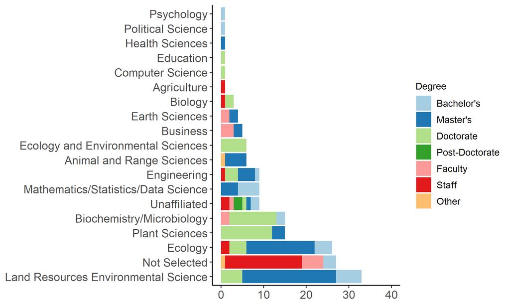

## Backgrounds of Attendees

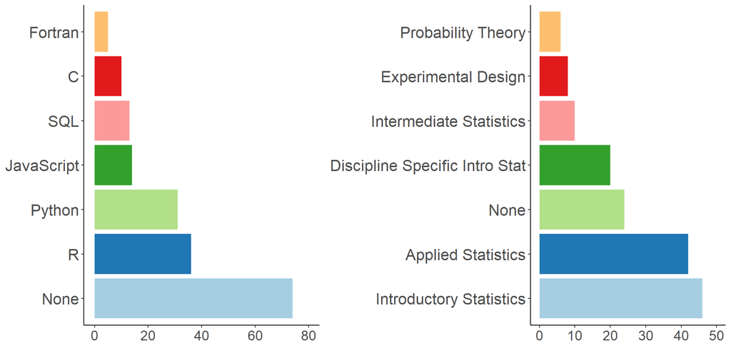

## Reasons for Attending Workshops

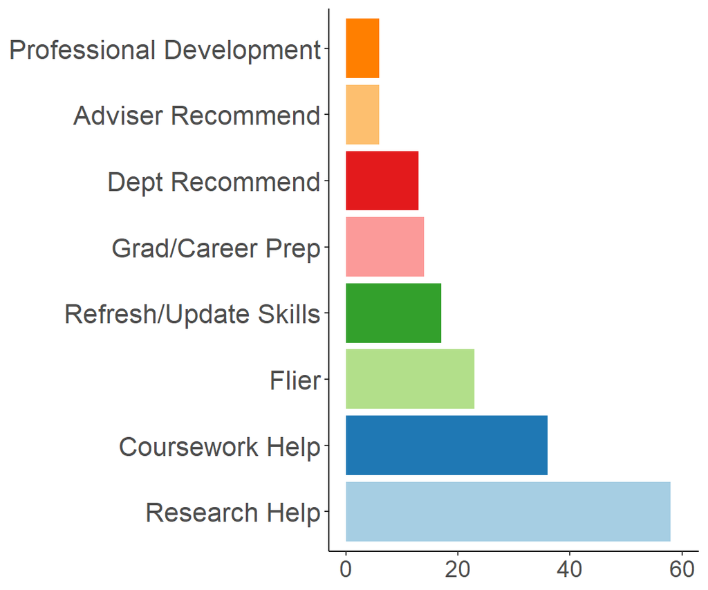

## Resources Used to Learn `R`

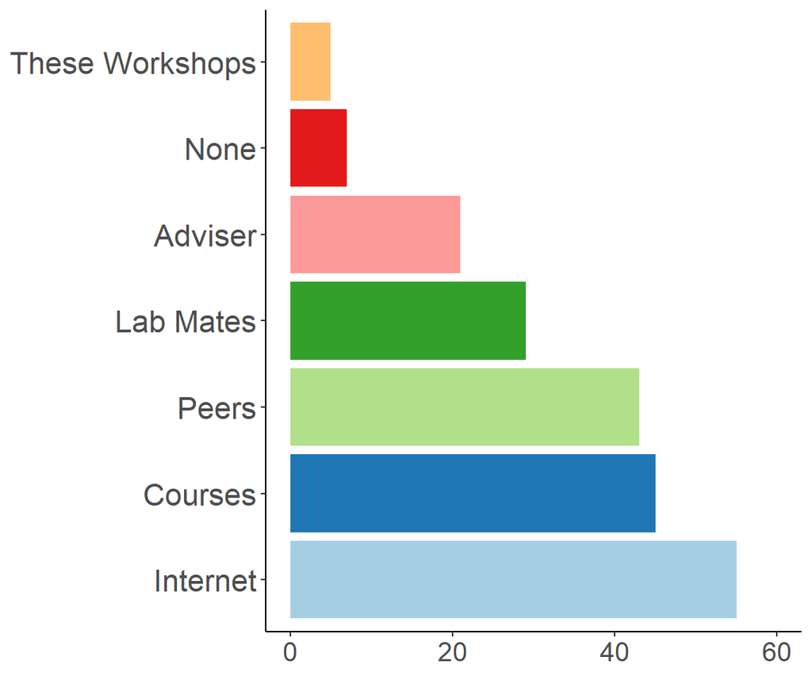

## Do These Skills Capture What Researchers Use?

- Collection of the `R` code generated by environmental science graduate students provides insight into the key data science skills necessary for research in these fields
- Aids in reevaluating the content of these workshops, to ensure they cover the skills necessary for graduate-level environmental science research.

## Working in `R`

- Using `R` projects to promote better workflow practices
  - Working directories
  - Organized folder directory
- Using `RMarkdown` documents to promote better script writing
  - Organized sections of code
  - Allows for written descriptions
  - Promotes reproducibility

## Working with Data in `R`

- Handing a variety of data structures
- Wrangling data
  - Selecting columns
  - Filtering rows or elements
  - Creating new variables
  - Mutating existing variables

## Control Flow

- Conditional statements
  - Creating new variables by mutating existing variables
  - Function breaks
- Repeated operations
  - Sequences of steps being copied-and-pasted
  - Looping
  - User-defined functions
  - Vectorization

## Data Presentations

- Data summaries
  - Statistical summaries of groups

[figure not shown]

- Data visualizations
  - Adding facets
  - Plotting specifications

## Dissemination of Research

- Infusing the skills outlined by this research into Data Carpentry’s *Data Analysis and Visualization in `R` for Ecologists* curriculum
- Creating lessons through the Carpentries Incubator and Carpentries Lab
  - Focusing on teaching the skills outlined by this research, not currently included in the Carpentries curriculum

## Considerations & Future Directions

- Attendance of these workshops by many individuals outside of environmental science disciplines brings to question if this type of tailored design work is necessary.
  - Are there common data science skills necessary for research in **any** scientific field?
- A larger number of attendees from environmental science fields persisted across workshops.
  - What are the drivers behind these individuals’ continued attendance?
  - Investigating the learning outcomes of workshop attendees could provide insight into the necessity of these discipline-specific learning opportunities.

## Many Thanks

- Stacey Hancock
- Mary Alice Carlson, Jenny Green, & Megan Wickstrom
- Sara Mannheimer & Mark Greenwood
- Workshop facilitators and helpers
- Environmental Science faculty and graduate students

## References

http://bit.ly/kopriva_theobold

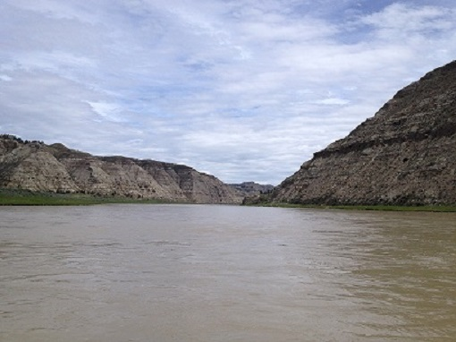

## Thank you!

Workshop Repository:

https://github.com/atheobold/data-science-workshops

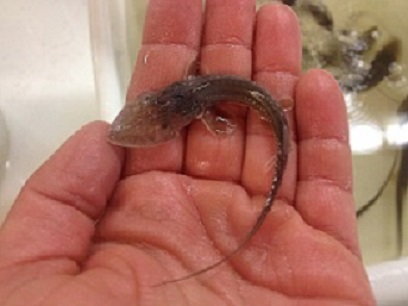

Workshops in RStudio Cloud:

http://bit.ly/introductionR  
http://bit.ly/intermediate-R  
http://bit.ly/data-vizz  
http://bit.ly/data-wrangle

allisontheobld@montana.edu  
http://www.math.montana.edu/allison_theobold/  
@mtstatistics

## What is `R`?

```
inherits(R, "S") == TRUE
```

- It’s a dialect of S!
- Created because the commonly used data analysis packages had some key downsides:
  - Graphics were too “quick and dirty”
  - Relatively little ability to build custom tools
- “`R` is a free software environment for statistical computing and graphics.”
- “The `tidyverse` is an opinionated collection of R packages designed for data science.”

## Why `tidyverse`?

> Programs must be written for people to read, and only incidentally for machines to execute.  
> - Hal Abelson

```r
sample_n(airquality, 8)
```

```
##   Ozone Solar.R Wind Temp Month Day
## 1    NA      66 16.6   57     5  25
## 2     7      NA  6.9   74     5  11
## 3    NA     194  8.6   69     5  10
## 4    NA     186  9.2   84     6   4
## 5    NA     259 10.9   93     6  11
## 6     1       8  9.7   59     5  21
## 7    20      37  9.2   65     6  18
## 8     8      19 20.1   61     5   9
```

## Means of Groups – `tidyverse`

```r
group_by(airquality, Month) %>%
  summarize(o3 = mean(Ozone, na.rm = TRUE))
```

```r
aggregate(airquality,
          list(Month = airquality[, "Month"]),
          mean,
          na.rm = TRUE)
```

```
##   Month    Ozone  Solar.R      Wind     Temp Month  Day
## 1     5 23.61538 181.2963 11.622581 65.54839     5 16.0
## 2     6 29.44444 190.1667 10.266667 79.10000     6 15.5
## 3     7 59.11538 216.4839  8.941935 83.90323     7 16.0
## 4     8 59.96154 171.8571  8.793548 83.96774     8 16.0
## 5     9 31.44828 167.4333 10.180000 76.90000     9 15.5
```

## Why so complicated?

```r
aggregate(airquality,
          list(Month = airquality[, "Month"]),
          mean,
          na.rm = TRUE)
```

1. What are the square brackets `[` for ?
2. What is `list()`?
3. Why is the `mean()` function just sitting there all by itself?
4. Is `na.rm = TRUE` an argument to aggregate()?

## Research Journey

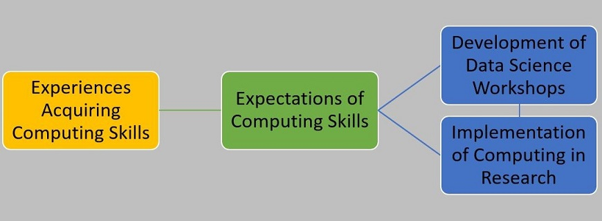